# AI_CA4_810199461

In the name of god

Ali Ataollahi / 810199461

AI_FALL_1401 / CA4 / ML

## Import Dependencies

```python
import pandas as pd
from math import *
import matplotlib.pyplot as plt
```

# Part 1 : EDA and vectorization

Read data and put it in data_frame.

```python
data_frame = pd.read_csv("./diabetes.csv")
data_frame
```

|  | Pregnancies | Glucose | BloodPressure | SkinThickness | Insulin | BMI | DiabetesPedigreeFunction | Age | Outcome |
| --- | --- | --- | --- | --- | --- | --- | --- | --- | --- |
| 0 | 6.0 | 148.0 | 72.0 | 35.0 | 0.0 | 33.6 | 0.627 | 50.0 | 1 |
| 1 | 1.0 | 85.0 | 66.0 | 29.0 | 0.0 | 26.6 | 0.351 | 31.0 | 0 |
| 2 | NaN | 183.0 | 64.0 | 0.0 | 0.0 | 23.3 | 0.672 | 32.0 | 1 |
| 3 | 1.0 | 89.0 | 66.0 | 23.0 | 94.0 | 28.1 | 0.167 | 21.0 | 0 |
| 4 | NaN | 137.0 | 40.0 | 35.0 | 168.0 | NaN | NaN | 33.0 | 1 |
| ... | ... | ... | ... | ... | ... | ... | ... | ... | ... |
| 763 | 10.0 | 101.0 | 76.0 | 48.0 | 180.0 | 32.9 | NaN | 63.0 | 0 |
| 764 | 2.0 | 122.0 | 70.0 | NaN | 0.0 | 36.8 | 0.340 | NaN | 0 |
| 765 | 5.0 | NaN | 72.0 | 23.0 | 112.0 | 26.2 | 0.245 | 30.0 | 0 |
| 766 | 1.0 | 126.0 | 60.0 | NaN | 0.0 | 30.1 | 0.349 | NaN | 1 |
| 767 | NaN | 93.0 | NaN | 31.0 | NaN | 30.4 | 0.315 | 23.0 | 0 |

768 rows × 9 columns

#### Question 1

info : it prints some information for data_frame describe : with this we can find out some statical info like mean, std, min, max, ... about data_frame

```python
data_frame.info()
```

```
<class 'pandas.core.frame.DataFrame'>
RangeIndex: 768 entries, 0 to 767
Data columns (total 9 columns):
 #   Column                    Non-Null Count  Dtype
---  ------                    --------------  -----
 0   Pregnancies               635 non-null    float64
 1   Glucose                   654 non-null    float64
 2   BloodPressure             680 non-null    float64
 3   SkinThickness             624 non-null    float64
 4   Insulin                   680 non-null    float64
 5   BMI                       684 non-null    float64
 6   DiabetesPedigreeFunction  590 non-null    float64
 7   Age                       655 non-null    float64
 8   Outcome                   768 non-null    int64
dtypes: float64(8), int64(1)
memory usage: 54.1 KB
```

```python
data_frame.describe()
```

|  | Pregnancies | Glucose | BloodPressure | SkinThickness | Insulin | BMI | DiabetesPedigreeFunction | Age | Outcome |
| --- | --- | --- | --- | --- | --- | --- | --- | --- | --- |
| count | 635.000000 | 654.000000 | 680.000000 | 624.000000 | 680.000000 | 684.000000 | 590.000000 | 655.000000 | 768.000000 |
| mean | 3.700787 | 113.422018 | 68.786765 | 20.386218 | 80.123529 | 32.083626 | 0.466676 | 33.157252 | 0.348958 |
| std | 3.518126 | 202.816831 | 19.724841 | 15.987049 | 115.681140 | 7.800741 | 0.322408 | 13.829831 | 0.476951 |
| min | -22.000000 | -5000.000000 | -2.000000 | 0.000000 | 0.000000 | 0.000000 | 0.078000 | -150.000000 | 0.000000 |
| 25% | 1.000000 | 99.000000 | 62.000000 | 0.000000 | 0.000000 | 27.375000 | 0.243250 | 24.000000 | 0.000000 |
| 50% | 3.000000 | 117.000000 | 72.000000 | 23.000000 | 34.000000 | 32.300000 | 0.368000 | 29.000000 | 0.000000 |
| 75% | 6.000000 | 140.750000 | 80.000000 | 32.000000 | 129.250000 | 36.600000 | 0.611500 | 41.000000 | 1.000000 |
| max | 17.000000 | 199.000000 | 122.000000 | 99.000000 | 846.000000 | 67.100000 | 2.329000 | 81.000000 | 1.000000 |

#### Question 2

```python
data_frame.isnull().sum()
```

```
Pregnancies                 133
Glucose                     114
BloodPressure                88
SkinThickness               144
Insulin                      88
BMI                          84
DiabetesPedigreeFunction    178
Age                         113
Outcome                       0
dtype: int64
```

```python
miss_percentages = data_frame.isnull().sum() / len(data_frame) * 100
miss_percentages
```

```
Pregnancies                 17.317708
Glucose                     14.843750
BloodPressure               11.458333
SkinThickness               18.750000
Insulin                     11.458333
BMI                         10.937500
DiabetesPedigreeFunction    23.177083
Age                         14.713542
Outcome                      0.000000
dtype: float64
```

#### Question 3

[output not shown]

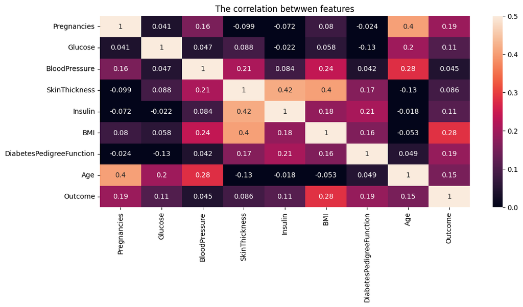

```python
import seaborn as sns

plt.subplots(figsize=(12,5))
corr = data_frame.corr()
sns.heatmap(corr, annot=True, vmin=0, vmax=0.5)
plt.title('The correlation betwwen features')
plt.xticks(rotation=90)
```

```python
data_frame.corr()['Outcome'].sort_values(ascending=False)
```

```
Outcome                     1.000000
BMI                         0.284374
Pregnancies                 0.193306
DiabetesPedigreeFunction    0.186958
Age                         0.152902
Insulin                     0.112239
Glucose                     0.105518
SkinThickness               0.086170
BloodPressure               0.044803
Name: Outcome, dtype: float64
```

Now we can say BMI has most correlation

#### Question 4

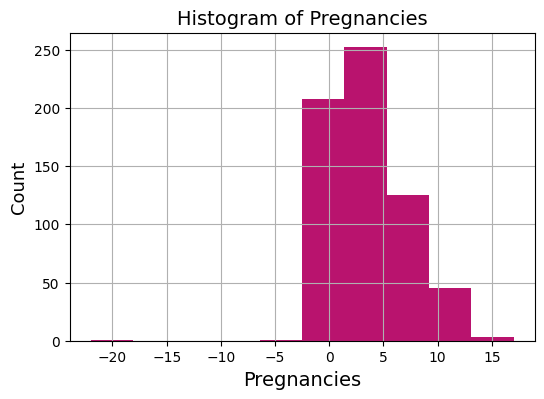

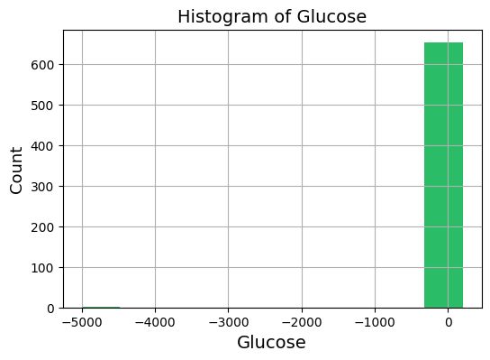

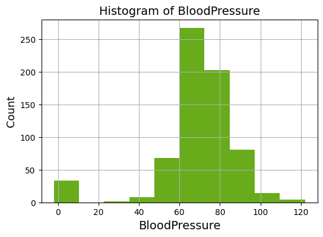

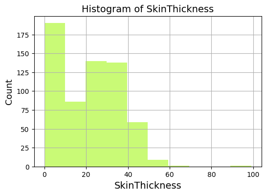

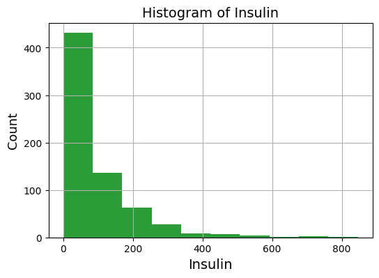

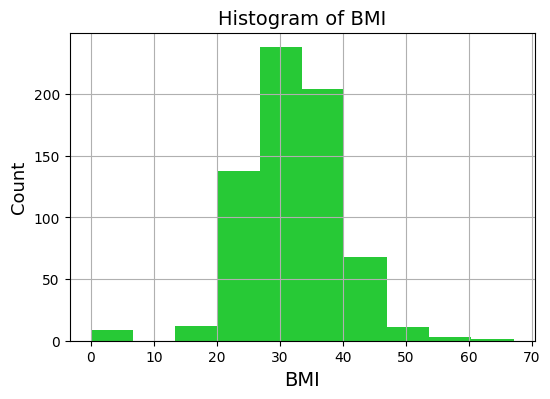

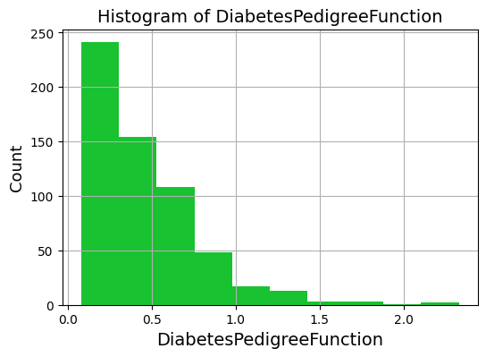

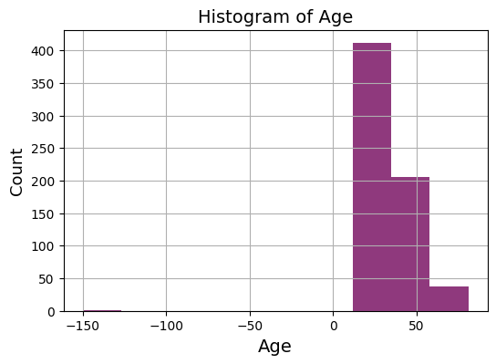

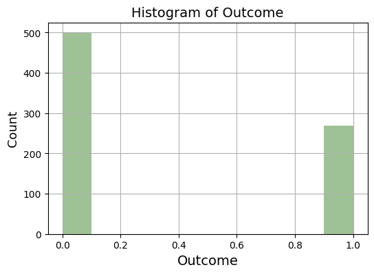

```python
import random
import matplotlib.pyplot as plt
for title in data_frame.columns:
    plt.figure()
    plt.title('Histogram of ' + title, fontsize = 14)
    plt.xlabel(title, fontsize = 14)
    plt.ylabel('Count', fontsize = 13)
    randomColor = ["#"+''.join([random.choice('ABCDEF0123456789') for i in range(6)])]
    data_frame[title].hist(color = randomColor, figsize=(6,4))
```

#### Question 5

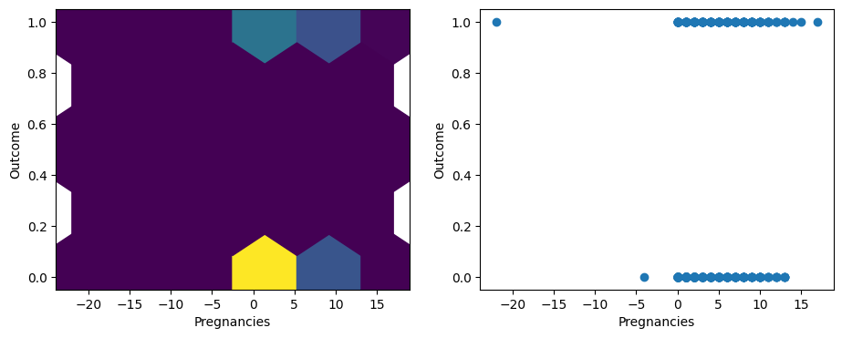

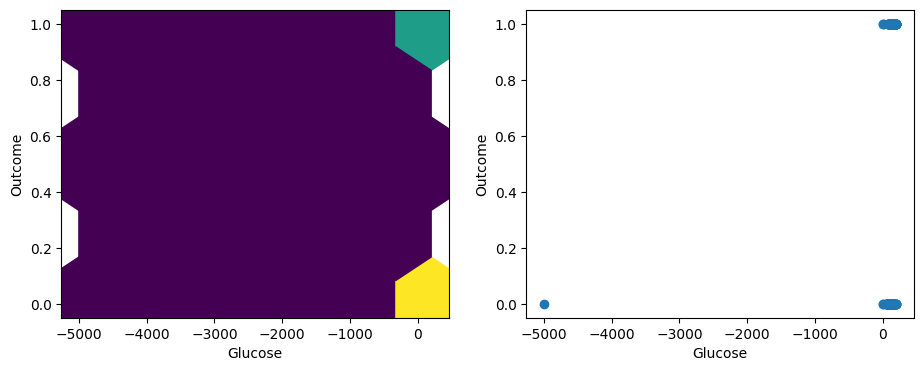

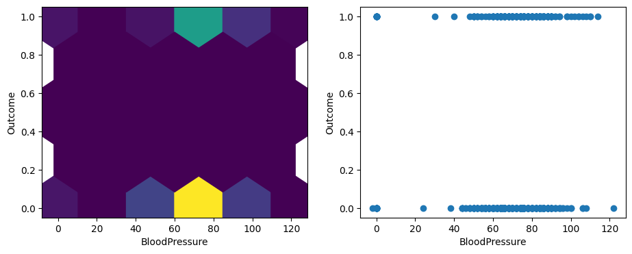

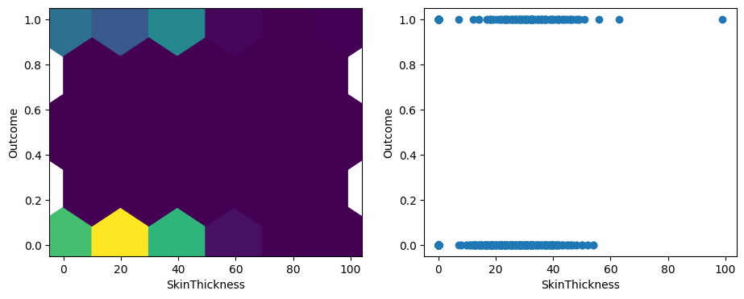

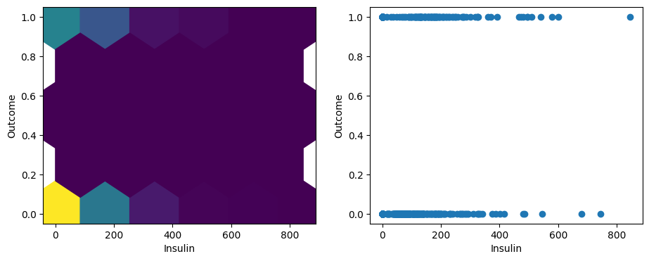

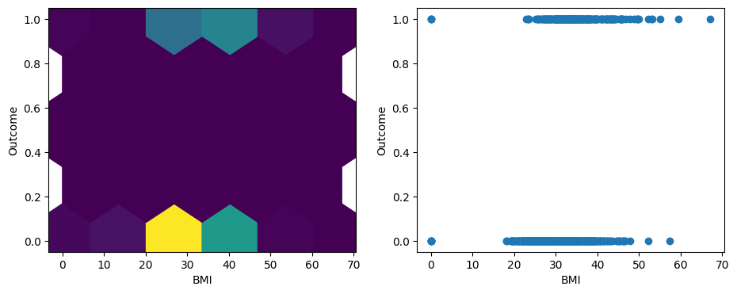

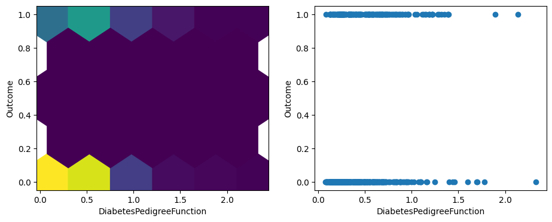

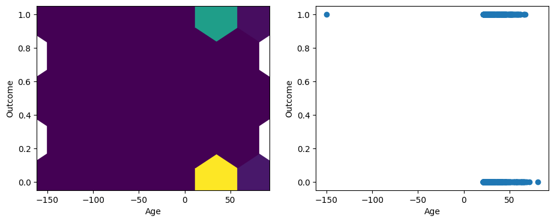

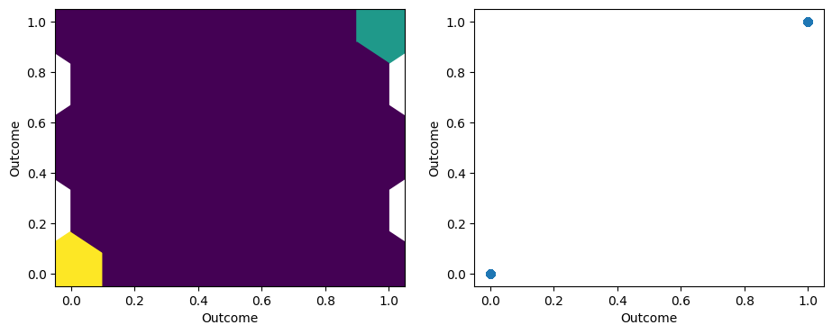

```python
def hexbin(column):
    plt.subplot(121)
    plt.xlabel(column)
    plt.ylabel("Outcome")
    plt.hexbin(data_frame[column], data_frame["Outcome"], gridsize = 5)

def scatter(column):
    plt.subplot(122)
    plt.xlabel(column)
    plt.ylabel("Outcome")
    plt.scatter(data_frame[column], data_frame["Outcome"])

def plot_information(column):
    fig = plt.figure(figsize=(11,4))
    hexbin(column)
    scatter(column)

for title in data_frame:
    plot_information(title)
```

#### Question 6

It is enough :)

# Part 2 : Preprocess

#### Question 1

- Use mean or mod for replacing NAN values :

This soloution is very easy to implement and output of that is nice. But in some cases we have more missing values and replacing that with mean or mod can not train our model more and doesn't give to us more data.

- Delete col that contain many missing values:

It is used when we have a lot missing values and replacing with mean or mod is not efficient way. But in other hand it cause we lose some info.

#### Question 2

```python
miss_percentages
```

```
Pregnancies                 17.317708
Glucose                     14.843750
BloodPressure               11.458333
SkinThickness               18.750000
Insulin                     11.458333
BMI                         10.937500
DiabetesPedigreeFunction    23.177083
Age                         14.713542
Outcome                      0.000000
dtype: float64
```

DiabetesPedigreeFunction has most = 23%

So it is better to delete this col.

```python
def drop_cols(title):
    data_frame.drop(title, axis = 1, inplace = True)

droped_titles = ["DiabetesPedigreeFunction"]
for title in droped_titles:
    drop_cols(title)


def fill_nan_with_mean(col, with_ceil=False):
    mean_val = ceil(col.mean()) if with_ceil else col.mean()
    col.fillna(mean_val, inplace=True)

titles_fill_with_mean = ["Glucose", "BloodPressure", "SkinThickness", "Insulin", "BMI",]
for title in titles_fill_with_mean:
    fill_nan_with_mean(data_frame[title])
fill_nan_with_mean(data_frame["Age"])


def fill_nan_with_mod(col):
    col.fillna(col.mode()[0], inplace=True)

titles_fill_with_mod = ["Pregnancies"]
for title in titles_fill_with_mod:
    fill_nan_with_mod(data_frame[title])

data_frame.isnull().sum()
```

```
Pregnancies      0
Glucose          0
BloodPressure    0
SkinThickness    0
Insulin          0
BMI              0
Age              0
Outcome          0
dtype: int64
```

```python
data_frame
```

|  | Pregnancies | Glucose | BloodPressure | SkinThickness | Insulin | BMI | Age | Outcome |
| --- | --- | --- | --- | --- | --- | --- | --- | --- |
| 0 | 6.0 | 148.000000 | 72.000000 | 35.000000 | 0.000000 | 33.600000 | 50.000000 | 1 |
| 1 | 1.0 | 85.000000 | 66.000000 | 29.000000 | 0.000000 | 26.600000 | 31.000000 | 0 |
| 2 | 1.0 | 183.000000 | 64.000000 | 0.000000 | 0.000000 | 23.300000 | 32.000000 | 1 |
| 3 | 1.0 | 89.000000 | 66.000000 | 23.000000 | 94.000000 | 28.100000 | 21.000000 | 0 |
| 4 | 1.0 | 137.000000 | 40.000000 | 35.000000 | 168.000000 | 32.083626 | 33.000000 | 1 |
| ... | ... | ... | ... | ... | ... | ... | ... | ... |
| 763 | 10.0 | 101.000000 | 76.000000 | 48.000000 | 180.000000 | 32.900000 | 63.000000 | 0 |
| 764 | 2.0 | 122.000000 | 70.000000 | 20.386218 | 0.000000 | 36.800000 | 33.157252 | 0 |
| 765 | 5.0 | 113.422018 | 72.000000 | 23.000000 | 112.000000 | 26.200000 | 30.000000 | 0 |
| 766 | 1.0 | 126.000000 | 60.000000 | 20.386218 | 0.000000 | 30.100000 | 33.157252 | 1 |
| 767 | 1.0 | 93.000000 | 68.786765 | 31.000000 | 80.123529 | 30.400000 | 23.000000 | 0 |

768 rows × 8 columns

#### Question 3

Normalization And Standardization:

We reduce the range of data values with these methods. so the scale of features doesn't affect our prediction.

Normalization : rescales the values into a range of (0,1).It is useful when we don’t know about the distribution.

$X_{new} = (X - X_{min})/(X_{max} - X_{min})$

Standardization: rescales data to have a mean of 0 and a standard deviation of 1.It is useful when the feature distribution is normal or Gaussian.

$X_{new} = (X - mean)/std$

Which one is better ? it depends to out application. A normalized dataset will always have values between 0 to 1. A standardized dataset have a mean of 0 and standard deviation of 1. There is no upper or lower bound for the max or min values.

```python
temp_outcome = data_frame["Outcome"]
normalized_data_frame = data_frame.apply(lambda col : col if isinstance(col[0], str) else (col - col.mean()) / col.std())
normalized_data_frame["Outcome"] = temp_outcome
normalized_data_frame.head()
```

|  | Pregnancies | Glucose | BloodPressure | SkinThickness | Insulin | BMI | Age | Outcome |
| --- | --- | --- | --- | --- | --- | --- | --- | --- |
| 0 | 0.823959 | 0.184772 | 0.173138 | 1.014257 | -0.736140 | 0.205996 | 1.318879 | 1 |
| 1 | -0.664983 | -0.151877 | -0.150158 | 0.597832 | -0.736140 | -0.744937 | -0.168925 | 0 |
| 2 | -0.664983 | 0.371800 | -0.257924 | -1.414888 | -0.736140 | -1.193233 | -0.090619 | 1 |
| 3 | -0.664983 | -0.130502 | -0.150158 | 0.181407 | 0.127491 | -0.541165 | -0.951979 | 0 |
| 4 | -0.664983 | 0.125992 | -1.551108 | 1.014257 | 0.807370 | 0.000000 | -0.012314 | 1 |

#### Question 4

#### Categorical values:

There are a lot of ways to handle categorical features and in the below we enumerate some of that. It is very important to know that we don't handle all of this type of data in a way and select one of that depend of type of data. some of that are :

- Nominal: In this way, classified traits take out of order different values. And features will have no numerical value. One-hot can be used for encryption in this way.
- Binary: In this way, only zero and one can be give to classified features.
- Ordinal: In this way, classified features can take in order different values.

According to values we have in dataset, we won't need any of this.

#### Question 5

If we want to speed up the operation of prediction and modeling in faster way we can delete some of cols addition to col that have many missing values

We can delete some of cols that have less correlation to outcome like SkinThickness and BloodPressure. But for better accuracy we won't delete this cols.

#### Question 6

#### Data splitting (train, test, validation)

there is different ways such as:

- Cross validation : In this way, we have to step.

first step :a part of the data is chosen as train and the rest is chosen as validation data.  
second step : this definition is switched and the train part becomes the validation part.

- Leave-percentage-out : In this way, we mark p percentage of the train_data as test part. After learning with the train part, we can test_data the learnings on the validation data. If all of this works output is not fine we repeat all of that.
- holdout : use sklearn.train_test_split().

```python
from sklearn.model_selection import train_test_split
input = normalized_data_frame[normalized_data_frame.columns.difference(["Outcome"])]
out = normalized_data_frame["Outcome"]
input_train, input_test, output_train, output_test = train_test_split(input, out, shuffle=True, train_size = 0.55)
print(input_train)
print(input_test)
```

```
          Age       BMI  BloodPressure   Glucose   Insulin  Pregnancies  \
294  2.493460 -1.383420      -1.012281  0.254240 -0.736140    -0.962771
408  0.457519 -0.840030       0.280903  0.446611 -0.736140     1.419535
155  0.222603  2.433894       1.035261  0.000000 -0.736140     1.121747
757  0.000000  0.572784       0.173138  0.051181 -0.736140    -0.962771
199 -0.325535 -0.160793      -0.473455  0.184772  2.185505     0.228382
..        ...       ...            ...       ...       ...          ...
599 -0.560452 -1.220403      -1.658874 -0.023630  0.366368    -0.664983
549  0.300908  0.000000       0.000000  0.403861 -0.736140    -0.664983
481 -0.325535  0.423351       1.035261  0.051181 -0.736140    -0.962771
266 -0.638757  0.000000      -3.706416  0.131336 -0.736140    -0.962771
58   0.849046  1.143343       0.711965  0.174085 -0.736140    -0.962771

     SkinThickness
294  -1.414888e+00
```

[output cut: 39 more lines]

#### Question 7

#### Validation data

It is set of data while tuning model hyperparams used to provide evaluation of a model fitted that is unbiased on the train_data. Also in other forms of model preparation it has very role, like cut-off threshold selection, feature selection, ... .

# Part 3 : Training

```python
from sklearn.metrics import confusion_matrix, ConfusionMatrixDisplay, accuracy_score
from sklearn.tree import DecisionTreeClassifier
from sklearn import tree
from sklearn.metrics import classification_report
from sklearn import tree

def plot_success_rate(actual_output, predict_output, title):
    matrix = confusion_matrix(actual_output, predict_output)
    cm_display = ConfusionMatrixDisplay(confusion_matrix = matrix)
    accurancy = accuracy_score(actual_output, predict_output) * 100
    cm_display.plot()
    cm_display.ax_.set_title(f"{title} accurancy = {accurancy}%")

def predict_and_print_report(classfier, print_tree=False):
    classfier.fit(input_train, output_train)
    train_predict = classfier.predict(input_train)
    test_predict = classfier.predict(input_test)
    if print_tree:
        tree.plot_tree(classfier.fit(input_train, output_train))
    print(classification_report(output_train, train_predict))
    print(classification_report(output_test, test_predict))
    plot_success_rate(train_predict, output_train, 'train_maxtrix')
    plot_success_rate(test_predict, output_test, 'test_maxtrix')
```

### Decision Tree

```
              precision    recall  f1-score   support

           0       0.75      0.96      0.84       279
           1       0.81      0.36      0.50       143

    accuracy                           0.76       422
   macro avg       0.78      0.66      0.67       422
weighted avg       0.77      0.76      0.72       422

              precision    recall  f1-score   support

           0       0.74      0.90      0.81       221
           1       0.70      0.43      0.53       125

    accuracy                           0.73       346
   macro avg       0.72      0.66      0.67       346
weighted avg       0.72      0.73      0.71       346
```

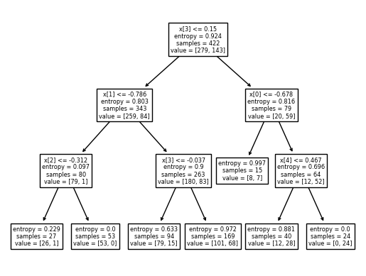

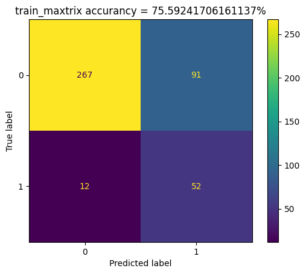

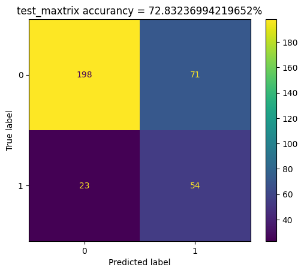

```python
dec_classifier = DecisionTreeClassifier(criterion='entropy', max_depth=3, min_samples_leaf=10)
predict_and_print_report(dec_classifier, print_tree=True)
```

### Use GridSearchCv to find best parameters

```python
from sklearn.model_selection import GridSearchCV, train_test_split
from sklearn.pipeline import Pipeline
from sklearn.preprocessing import StandardScaler
from sklearn import decomposition
gscv = GridSearchCV(Pipeline(steps=[('std_slc', StandardScaler()),
                        ('pca',  decomposition.PCA()),
                        ('dec_tree', tree.DecisionTreeClassifier())]),
                    dict(pca__n_components = list(range(1, input_train.shape[1] + 1, 1)),
                    dec_tree__max_depth = [1, 2, 3, 4, 5, 6, 7, 8, 9, 10],
                    dec_tree__criterion = ['gini', 'entropy']))
gscv.fit(input_train, output_train)
```

```
GridSearchCV(estimator=Pipeline(steps=[('std_slc', StandardScaler()),
                                       ('pca', PCA()),
                                       ('dec_tree', DecisionTreeClassifier())]),
             param_grid={'dec_tree__criterion': ['gini', 'entropy'],
                         'dec_tree__max_depth': [1, 2, 3, 4, 5, 6, 7, 8, 9, 10],
                         'pca__n_components': [1, 2, 3, 4, 5, 6, 7]})
```

```python
print('Best Parameters ')
print('-- num of components :', gscv.best_estimator_.get_params()['pca__n_components'])
print('-- max_depth :', gscv.best_estimator_.get_params()['dec_tree__max_depth'])
print('-- criterion :', gscv.best_estimator_.get_params()['dec_tree__criterion'])
```

```
Best Parameters
-- num of components : 6
-- max_depth : 4
-- criterion : gini
```

```
              precision    recall  f1-score   support

           0       0.79      0.94      0.86       279
           1       0.82      0.51      0.63       143

    accuracy                           0.80       422
   macro avg       0.81      0.73      0.74       422
weighted avg       0.80      0.80      0.78       422

              precision    recall  f1-score   support

           0       0.76      0.87      0.81       221
           1       0.70      0.51      0.59       125

    accuracy                           0.74       346
   macro avg       0.73      0.69      0.70       346
weighted avg       0.74      0.74      0.73       346
```

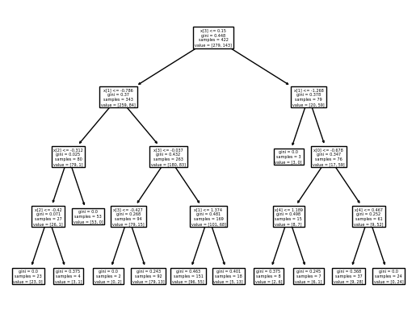

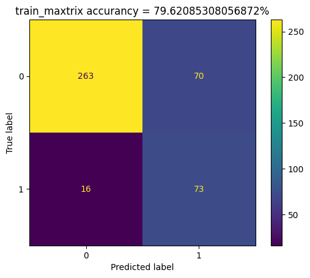

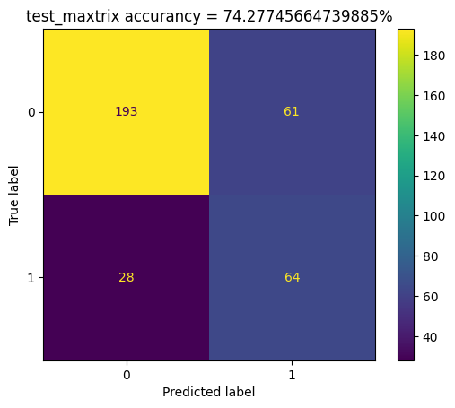

```python
dec_classifier = DecisionTreeClassifier(max_depth=gscv.best_estimator_.get_params()['dec_tree__max_depth'],
                                        criterion=gscv.best_estimator_.get_params()['dec_tree__criterion'])
predict_and_print_report(dec_classifier, print_tree=True)
```

### K-Nearest-Neighbours

```
best n for num of neighbors :  7
```

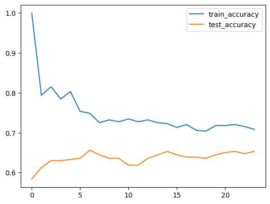

```python
from sklearn.neighbors import KNeighborsClassifier

train_accuracy, test_accuracy = [], []
best_index, best_score = 1, 0
for i in range(1, 25):
    knn_classifier = KNeighborsClassifier(n_neighbors = i)
    knn_classifier.fit(input_train, output_train)
    train_score = accuracy_score(output_train, knn_classifier.predict(input_train))
    test_score  = accuracy_score(output_test,  knn_classifier.predict(input_test))
    train_accuracy.append(train_score)
    test_accuracy.append(test_score)
    if best_score < test_score:
        best_index, best_score = i, test_score

print('best n for num of neighbors : ', best_index)
plt.plot(train_accuracy)
plt.plot(test_accuracy)
plt.legend(["train_accuracy", "test_accuracy"])
```

```
              precision    recall  f1-score   support

           0       0.78      0.87      0.82       279
           1       0.67      0.52      0.58       143

    accuracy                           0.75       422
   macro avg       0.72      0.69      0.70       422
weighted avg       0.74      0.75      0.74       422

              precision    recall  f1-score   support

           0       0.70      0.80      0.75       221
           1       0.53      0.41      0.46       125

    accuracy                           0.66       346
   macro avg       0.62      0.60      0.60       346
weighted avg       0.64      0.66      0.64       346
```

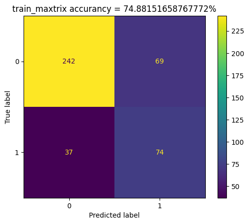

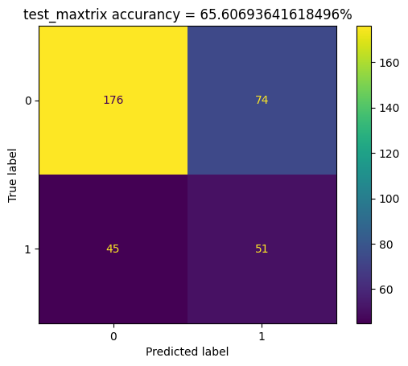

```python
knn_classifier = KNeighborsClassifier(n_neighbors = best_index)
predict_and_print_report(knn_classifier)
```

### Use GridSearchCv to find best parameters

```python
gscv = GridSearchCV(KNeighborsClassifier(),
                    dict(n_neighbors = list(range(1, 50))))
gscv_fit_res = gscv.fit(input_test, output_test)
print(gscv_fit_res.best_params_)
gscv_fit_res
```

```
{'n_neighbors': 24}
```

```
GridSearchCV(estimator=KNeighborsClassifier(),
             param_grid={'n_neighbors': [1, 2, 3, 4, 5, 6, 7, 8, 9, 10, 11, 12,
                                         13, 14, 15, 16, 17, 18, 19, 20, 21, 22,
                                         23, 24, 25, 26, 27, 28, 29, 30, ...]})
```

```
              precision    recall  f1-score   support

           0       0.71      0.94      0.81       279
           1       0.69      0.26      0.38       143

    accuracy                           0.71       422
   macro avg       0.70      0.60      0.59       422
weighted avg       0.70      0.71      0.66       422

              precision    recall  f1-score   support

           0       0.67      0.91      0.77       221
           1       0.56      0.20      0.29       125

    accuracy                           0.65       346
   macro avg       0.61      0.55      0.53       346
weighted avg       0.63      0.65      0.60       346
```

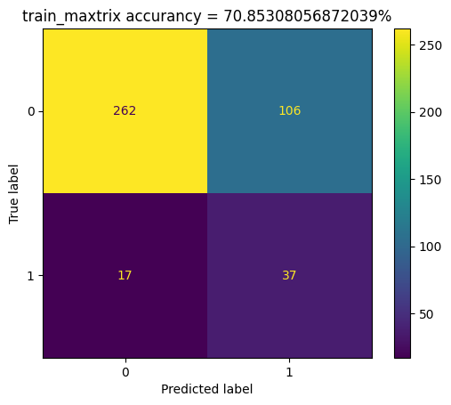

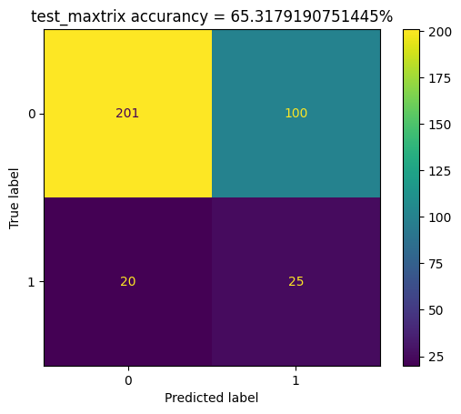

```python
knn_classifier = KNeighborsClassifier(n_neighbors=gscv_fit_res.best_params_['n_neighbors'])
predict_and_print_report(knn_classifier)
```

### Logistic Regression

```
              precision    recall  f1-score   support

           0       0.77      0.90      0.83       279
           1       0.71      0.48      0.57       143

    accuracy                           0.76       422
   macro avg       0.74      0.69      0.70       422
weighted avg       0.75      0.76      0.74       422

              precision    recall  f1-score   support

           0       0.75      0.86      0.80       221
           1       0.67      0.50      0.57       125

    accuracy                           0.73       346
   macro avg       0.71      0.68      0.69       346
weighted avg       0.72      0.73      0.72       346
```

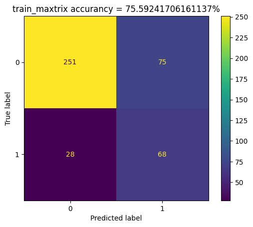

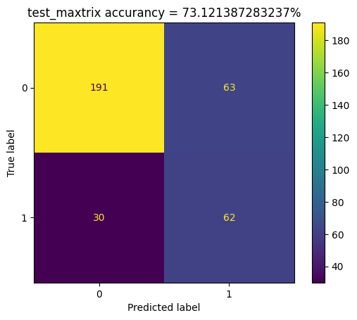

```python
from sklearn.linear_model import LogisticRegression

lr_classifier = LogisticRegression()
predict_and_print_report(lr_classifier)
```

### Use GridSearchCv to find best parameters

```python
from numpy import logspace

gscv = GridSearchCV(LogisticRegression(),
                   param_grid = {
                                    'C'       : logspace(-3, 3, 7),
                                    'solver'  : ['newton-cg', 'lbfgs', 'liblinear'],
                                },
                   scoring='accuracy',
                   cv=15)

gscv.fit(input_train,output_train)

print("Tuned Hyperparameters :", gscv.best_params_)
```

```
Tuned Hyperparameters : {'C': 1000.0, 'solver': 'newton-cg'}
```

```
              precision    recall  f1-score   support

           0       0.77      0.90      0.83       279
           1       0.71      0.48      0.57       143

    accuracy                           0.76       422
   macro avg       0.74      0.69      0.70       422
weighted avg       0.75      0.76      0.74       422

              precision    recall  f1-score   support

           0       0.75      0.86      0.80       221
           1       0.67      0.50      0.57       125

    accuracy                           0.73       346
   macro avg       0.71      0.68      0.69       346
weighted avg       0.72      0.73      0.72       346
```

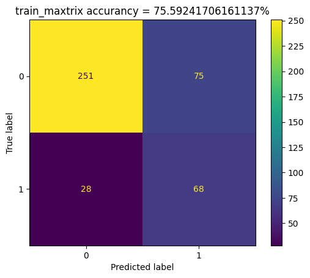

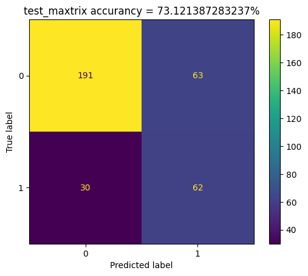

```python
logreg = LogisticRegression(C = gscv.best_params_["C"], solver = gscv.best_params_["solver"])
predict_and_print_report(lr_classifier)
```

#### Question 1

For calculate accuracy and other parameters we should use explanations that are discussed in class like tp, tn, fp, fn.

tn: The values which are actually negative and also predicted as negative.  
fn: The values which are actually positive but predicted as negative.  
fp: The values which are actually negative but predicted as positive.  
tp: The values which are actually positive and predicted as positive too.

#### Question 2

Job has done.

#### Question 3

- Overfitting : when the model fited on train data and performs very well on that but has not fine output for test data. In this case we modeled noise of train data.
- Underfitting : when model has bad performance on both datasets (train data and test data)

Cause of use built in and libraries and set params on that we have less overfitting and underfitting.

#### Question 4

Job has done and best preprocess applied.

# Part 4 : Random Forest

```
              precision    recall  f1-score   support

           0       1.00      1.00      1.00       279
           1       1.00      1.00      1.00       143

    accuracy                           1.00       422
   macro avg       1.00      1.00      1.00       422
weighted avg       1.00      1.00      1.00       422

              precision    recall  f1-score   support

           0       0.77      0.84      0.80       221
           1       0.66      0.55      0.60       125

    accuracy                           0.73       346
   macro avg       0.71      0.69      0.70       346
weighted avg       0.73      0.73      0.73       346
```

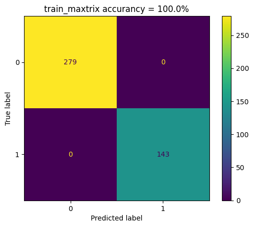

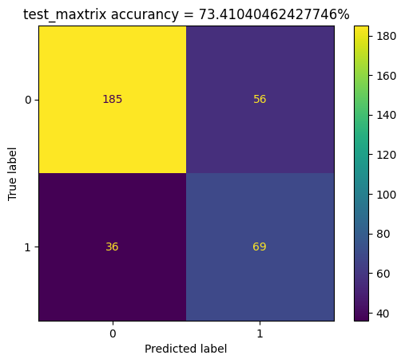

```python
from sklearn.ensemble import RandomForestClassifier

forest_classifire = RandomForestClassifier()
predict_and_print_report(forest_classifire)
```

### Search best parameters for random forest

```
best max_depth :  39
```

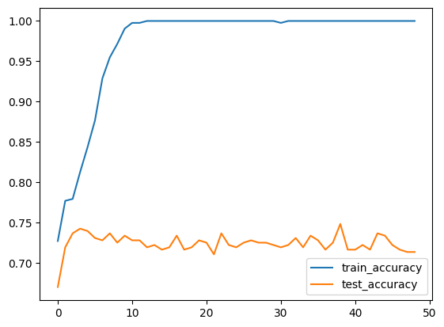

```python
train_accuracy, test_accuracy = [], []
best_max_depth, best_score = 1, 0
for i in range(1, 50):
    forest_classifire = RandomForestClassifier(max_depth = i)
    forest_classifire.fit(input_train, output_train)
    train_score = accuracy_score(output_train, forest_classifire.predict(input_train))
    test_score  = accuracy_score(output_test,  forest_classifire.predict(input_test))
    train_accuracy.append(train_score)
    test_accuracy.append(test_score)
    if best_score < test_score:
        best_max_depth, best_score = i, test_score

print('best max_depth : ', best_max_depth)
plt.plot(train_accuracy)
plt.plot(test_accuracy)
plt.legend(["train_accuracy", "test_accuracy"])
```

```
best min_samples_leaf :  25
```

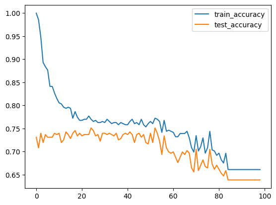

```python
train_accuracy, test_accuracy = [], []
best_min_samples_leaf, best_score = 1, 0
for i in range(1, 100):
    forest_classifire = RandomForestClassifier(max_depth=best_max_depth, min_samples_leaf = i)
    forest_classifire.fit(input_train, output_train)
    train_score = accuracy_score(output_train, forest_classifire.predict(input_train))
    test_score  = accuracy_score(output_test,  forest_classifire.predict(input_test))
    train_accuracy.append(train_score)
    test_accuracy.append(test_score)
    if best_score < test_score:
        best_min_samples_leaf, best_score = i, test_score

print('best min_samples_leaf : ', best_min_samples_leaf)
plt.plot(train_accuracy)
plt.plot(test_accuracy)
plt.legend(["train_accuracy", "test_accuracy"])
```

```
              precision    recall  f1-score   support

           0       0.77      0.95      0.85       279
           1       0.83      0.44      0.58       143

    accuracy                           0.78       422
   macro avg       0.80      0.70      0.71       422
weighted avg       0.79      0.78      0.76       422

              precision    recall  f1-score   support

           0       0.75      0.90      0.82       221
           1       0.72      0.46      0.56       125

    accuracy                           0.74       346
   macro avg       0.73      0.68      0.69       346
weighted avg       0.74      0.74      0.72       346
```

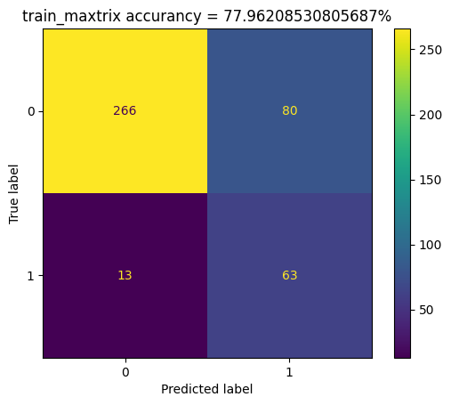

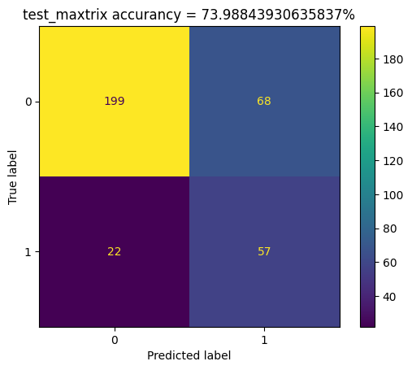

```python
forest_classifire = RandomForestClassifier(max_depth = best_max_depth, min_samples_leaf = best_min_samples_leaf)
predict_and_print_report(forest_classifire)
```

#### Question 1

Job has done.

#### Question 2

Bias and Variance relation

Bias : if our model systematically under or over predicts the target variable.  
Variance : captures the generalizability of the model.  
Best property : low bias and variance.  
Random Forest employs to reduce variance in predicts with some of techniques. It does this mostly by averaging together a number trees that have very weakly correlation.

The result is fine and near to expectations